# Test a Perceptual Phenomenon

### Analyzing the Stroop Effect

Perform the analysis in the space below. Remember to follow [the instructions](https://docs.google.com/document/d/1-OkpZLjG_kX9J6LIQ5IltsqMzVWjh36QpnP2RYpVdPU/pub?embedded=True) and review the [project rubric](https://review.udacity.com/#!/rubrics/71/view) before submitting. Once you've completed the analysis and write-up, download this file as a PDF or HTML file, upload that PDF/HTML into the workspace here (click on the orange Jupyter icon in the upper left then Upload), then use the Submit Project button at the bottom of this page. This will create a zip file containing both this .ipynb doc and the PDF/HTML doc that will be submitted for your project.

(1) What is the independent variable? What is the dependent variable?

###### The independent variable : a congruent word condition and an incongruent word condition.

###### The dependent variable : the time it takes to name the ink colors in equally sized lists .

(2) What is an appropriate set of hypotheses for this task? Specify your null and alternative hypotheses, and clearly define any notation used. Justify your choices.

###### Null Hypothesis (H0: μ1 = μ2) : There is no significant difference in the population average amount of time it takes to state the colors of the words in a congruent(μ1) or incongruent condition(μ2).

###### Alternative Hypothesis (H1: μ1 ≠ μ2): There is significant difference in the population average amount of time it takes to state the colors of the words in a congruent(μ1) or incongruent condition(μ2).

###### we should perform a dependent t-test for paired samples two samples and two-tail

###### Statistical test to perform in an attempt to determine the likelihood of each these hypotheses is a dependent measures t-test. It makes sense to perform a dependent measures test as all the subjects perform the Stroop task under both conditions Again, it makes sense to perform a t-test as the purpose of this project is to determine whether the population means of the results for the two conditions are different, but the population standard deviations are not known .

(3) Report some descriptive statistics regarding this dataset. Include at least one measure of central tendency and at least one measure of variability. The name of the data file is 'stroopdata.csv'.

```python
import pandas as pd
import numpy as np
import matplotlib.pyplot as plt
import seaborn as sns
import scipy.stats as stats
import math
%matplotlib inline
```

```python
df = pd.read_csv('stroopdata.csv')
df.head()
```

[output not shown]

```python
df.describe()
```

[output not shown]

###### Mean of the time for Congruent group: 14.051 ,

###### Mean of the time for Incongruent group: 22.015

###### Median of the time for Congruent group: 14.356 ,

###### Median of the time for Incongruent group: 21.0175

###### Standard deviation of the time for Congruent group: 3.559 ,

###### Standard deviation of the time for Incongruent group: 4.797

###### The Mean of Incongruent condition is higher that Congruent condition

###### The Median of Incongruent condition is higher that Congruent condition

###### Standard deviation for Incongurent indicating that distribution maybe wider in this case compared to Congurent condition.

(4) Provide one or two visualizations that show the distribution of the sample data. Write one or two sentences noting what you observe about the plot or plots.

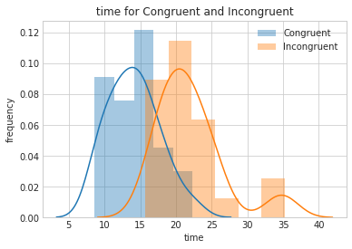

```python
sns.distplot(df['Congruent'],label = "Congruent")

sns.distplot(df['Incongruent'],label = "Incongruent")

plt.ylabel("frequency");

plt.xlabel("time");

plt.title(" time for Congruent and Incongruent ");
plt.legend();
```

###### histogram plots, although both graphs visually appear somewhat positively skewed,

###### the mean is close to the peak in both graphs which would indicate a normal distribution

(5) Now, perform the statistical test and report your results. What is your confidence level or Type I error associated with your test? What is your conclusion regarding the hypotheses you set up? Did the results match up with your expectations? **Hint:** Think about what is being measured on each individual, and what statistic best captures how an individual reacts in each environment.

```python
#Use a two sample two-tailed t-test for this analysis.
t, p = stats.ttest_rel(df['Incongruent'],df['Congruent'],axis=0)
```

```python
#Given p and t values from a two-tailed test.
(t, p)
```

```
(8.020706944109957, 4.1030005857111781e-08)
```

###### As p-value 4.1030-08 is smaller than 0.05, we reject the null hypothesis test that (H0: μ1 = μ2), therefore, I am 95% confident that the time the participant takes in the congruent words condition is different from the participant takes in the incongruent words condition. This is different from what i expect.

```python
df['difference'] = df['Incongruent'] -df['Congruent']
```

```python
df['difference'].describe()
```

```
count    24.000000
mean      7.964792
std       4.864827
min       1.950000
25%       3.645500
50%       7.666500
75%      10.258500
max      21.919000
Name: difference, dtype: float64
```

```python
d_bar = df['difference'].mean()


print("mean difference:", d_bar)
std = df['difference'].std()

print("standard deviation of the differences: ", std)
```

```
mean difference: 7.96479166667
standard deviation of the differences:  4.86482691036
```

```python
from math import *

SE_d_bar = df['difference'].std()/(sqrt(24))
print("standard error of the differences: ", SE_d_bar)
```

```
standard error of the differences:  0.993028634778
```

```python
t_statistic = df['difference'].mean()/SE_d_bar

print("t-statistic: ", t_statistic)
```

```
t-statistic:  8.02070694411
```

```python
#degree of freedom  = n-1 =23
df = 23
#Calculate T critical value
print(stats.t.ppf(1-0.025, df))
```

```
2.06865761042
```

###### t-statistic is less than t critical value -2.06865 or greater than 2.06865, we are 95% condifident ,

###### reject the null hypothesis.

### Resources:

https://imotions.com/blog/the-stroop-effect/

http://cfcc.edu/faculty/cmoore/0801-HypothesisTests.pdf

https://statistics.laerd.com/statistical-guides/dependent-t-test-statistical-guide.php.

https://towardsdatascience.com/inferential-statistics-series-t-test-using-numpy-2718f8f9bf2f